# QTM 151 - Introduction to Statistical Computing II

Lecture 08 - Custom Functions

Danilo Freire

danilo.freire@emory.edu

Emory University

25 September, 2024

# I hope you’re having a great day! 😊

# Brief recap of last class 📚

## Last class we learned about:

- Using `np.random.seed()` to set the seed for reproducibility
- Running simulations to estimate probabilities and expected values
  - `np.random.distribution()`
- How to simulate random variables from different distributions
  - `np.random.normal()`, `np.random.binomial()`, `np.random.poisson()`, etc
- Creating subplots with `plt.subplots()`
- Using `for` loops to iterate over a range of values

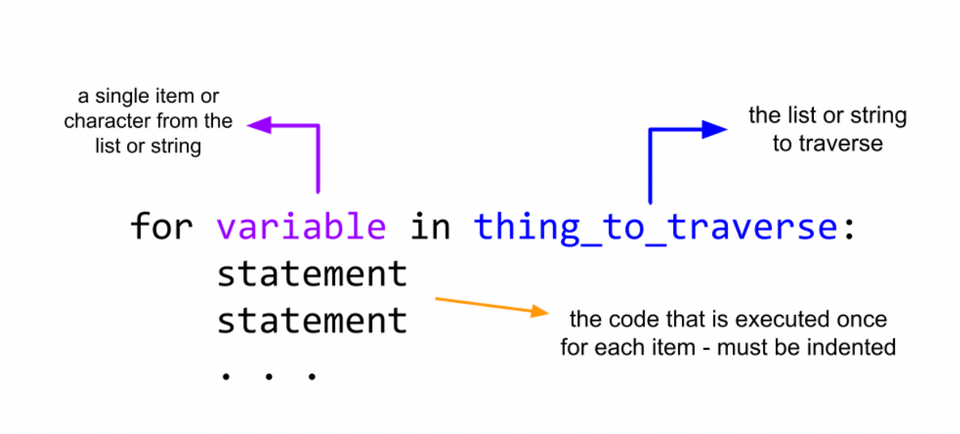

# Today’s plan 📋

## What we will do today:

- Learn about functions in Python
- Understand the difference between arguments, parameters, and return values
- Define functions with `def` and `return`
- Use functions to encapsulate repetitive code

## But first…

### Let’s just finish the last example from last class

- We were simulating how the uniform distribution behaves as we increase the number of samples
- We will finish this example and then move on to functions
- According to the Central Limit Theorem, the sample mean of a large number of random variables will be approximately normally distributed regardless of the distribution of the original random variables
- We will see how to write simulations and use a subplot to compare the distribution of the sample mean with the normal distribution

## Finishing the last example from last class

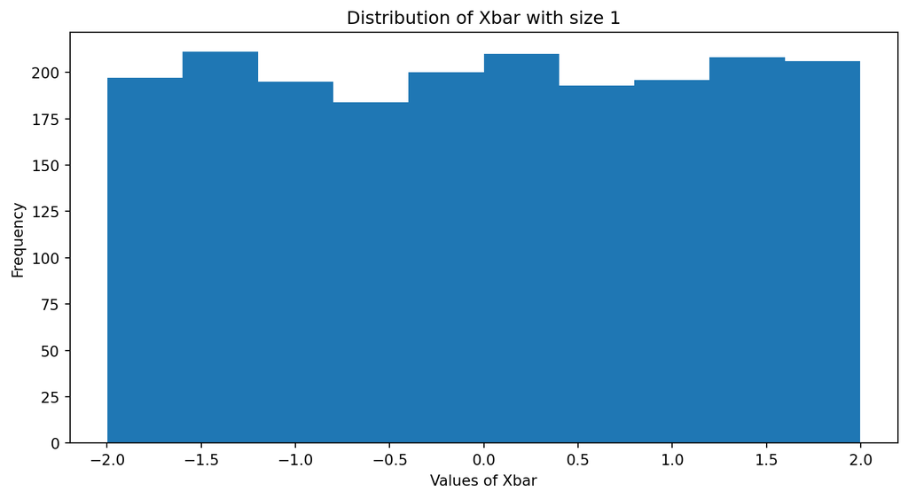

```python
## Importing libraries
import numpy as np
import matplotlib.pyplot as plt

## Setting the seed
np.random.seed(151)

## Number of simulations
num_simulations = 2000

# Simulate with sample size one
sample_size = 1
vec_xbar = [None] * num_simulations
for iteration in range(num_simulations):
    vec_unif  = np.random.uniform(low = -2, high=2, size = sample_size)
    vec_xbar[iteration] = vec_unif.mean()
plt.hist(vec_xbar)
plt.title("Distribution of Xbar with size 1")
plt.ylabel("Frequency")
plt.xlabel("Values of Xbar")
plt.show()
```

## Finishing the last example from last class

### Now using a for loop to simulate the sample mean for different sample sizes

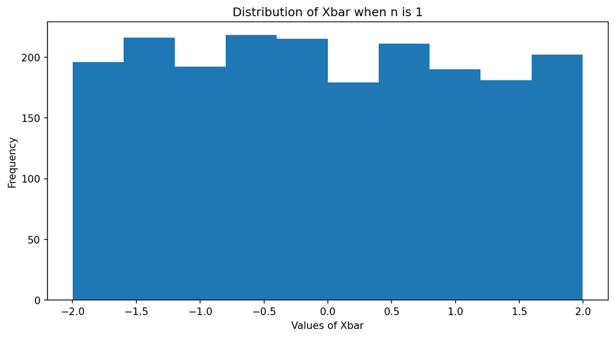

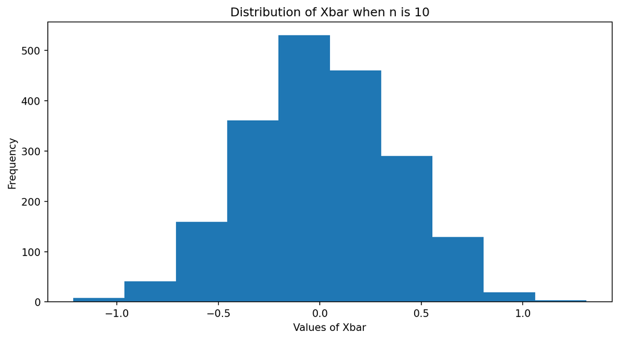

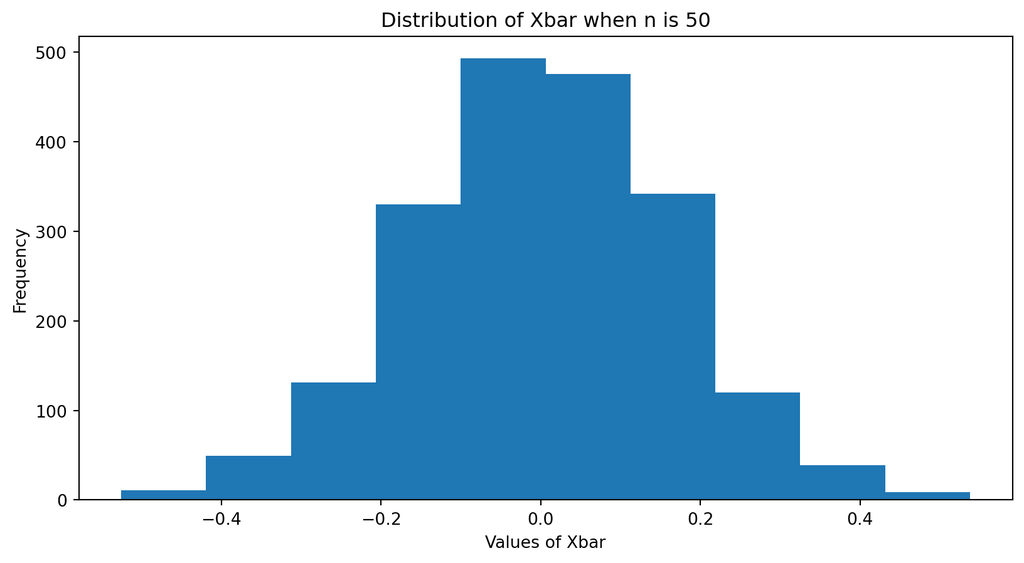

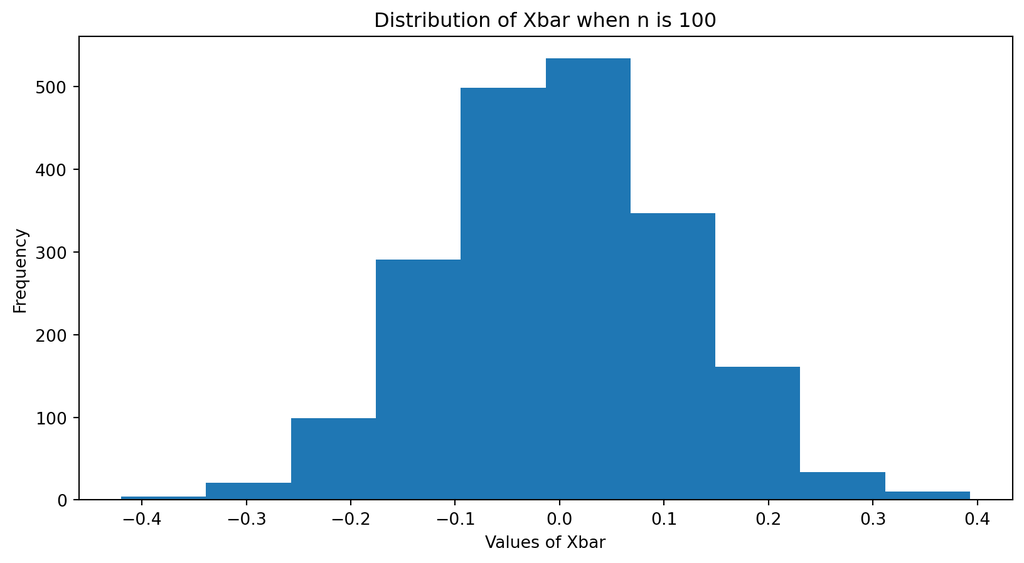

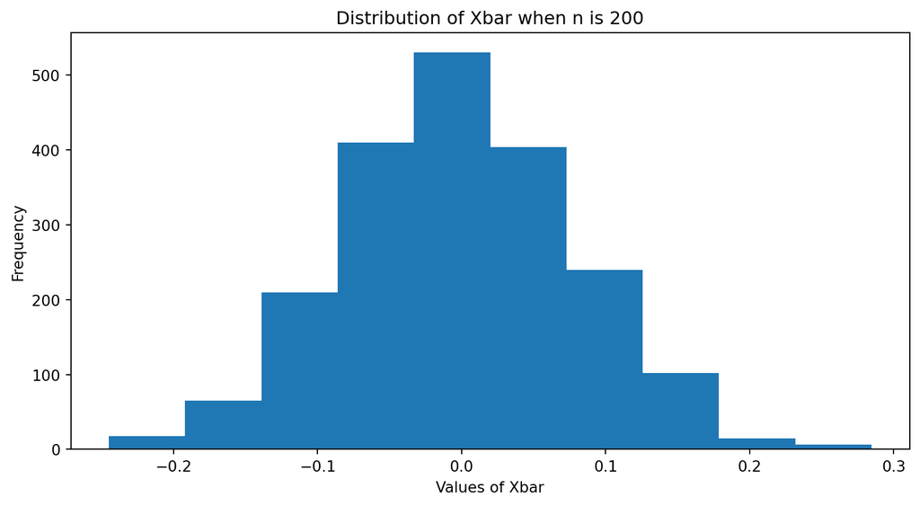

```python
num_simulations = 2000
sample_size_list = [1,10,50,100,200]

for sample_size in sample_size_list:

    # The following command a vector null values, of length "num_simulations"
    vec_xbar = [None] * num_simulations

    for iteration in range(num_simulations):
            vec_unif  = np.random.uniform(low = -2, high=2, size = sample_size)
            vec_xbar[iteration] = vec_unif.mean()
    plt.hist(vec_xbar)
    plt.title("Distribution of Xbar when n is " + str(sample_size))
    plt.ylabel("Frequency")
    plt.xlabel("Values of Xbar")
    plt.show()
```